# analise_respostas

Manoel Galdino

August 22, 2019

## Análise das resposas

Nós tivemos 65 formulários, mas apenas 62 colocaram sim no termo de ciência da pesquisa. Portanto, analiso aqui apenas os 62 que aceitaram ter seus dados analisados.

```
## # A tibble: 1 x 1
##   `n()`
##   <int>
## 1    62
```

Como enviamos dois tipos de questionários, eis os totais de respostas por questionário:

```
## # A tibble: 2 x 2
##   tipo  respostas
##   <chr>     <int>
## 1 A             9
## 2 B            53
```

## Demográficos

Vamos analisar os dados demográficos : UF e perfil do respondente

```
## [1] "UF"
```

```
## # A tibble: 5 x 3
##   uf    total  perc
##   <chr> <int> <dbl>
## 1 AL        1  0.02
## 2 PE        3  0.05
## 3 RJ        1  0.02
## 4 SC        1  0.02
## 5 SP       56  0.9
```

```
## [1] "Perfil do respondente"
```

```
## # A tibble: 3 x 3
##   sobre                   total  perc
##   <chr>                   <int> <dbl>
## 1 estudante                  44  0.71
## 2 funcionária/o da escola     6  0.1
## 3 mãe, pai ou responsável    12  0.19
```

Como se vê, há uma grande concentração de respostas no estado de São Paulo (90% das respostas).

## Hipóteses

Vamos começar agora a responder as hipóteses que orientaram a pesquisa. Nossa primeira investigação era sobre como perguntar a frequência com que as pessoas comiam a merenda. Como tivemos apenas 9 respostas no tipo A, o teste não é muito conclusivo.

De todo modo, o questionário A continha a seguinte pergunta: “Quantas Vezes Na Semana Você Costuma Comer As Refeições Oferecidas Pela Escola”

Já o questionario B perguntava: “Você Comeu As Refeições Oferecidas Pela Escola Mais De Uma Vez Neste Ano”

Eis as respostas para cada tipo de questionário

```
## [1] "Questionário A"
```

```
## # A tibble: 4 x 3
##   freq_comeu_A               total  perc
##   <chr>                      <int> <dbl>
## 1 5 ou mais vezes por semana     5  0.56
## 2 não como regularmente          2  0.22
## 3 nunca                          1  0.11
## 4 sempre                         1  0.11
```

```
## [1] "Questionário B"
```

```
## # A tibble: 2 x 3
##   freq_comeu_B total  perc
##   <chr>        <int> <dbl>
## 1 não             15  0.28
## 2 sim             38  0.72
```

```
## [1] "questionário B"
```

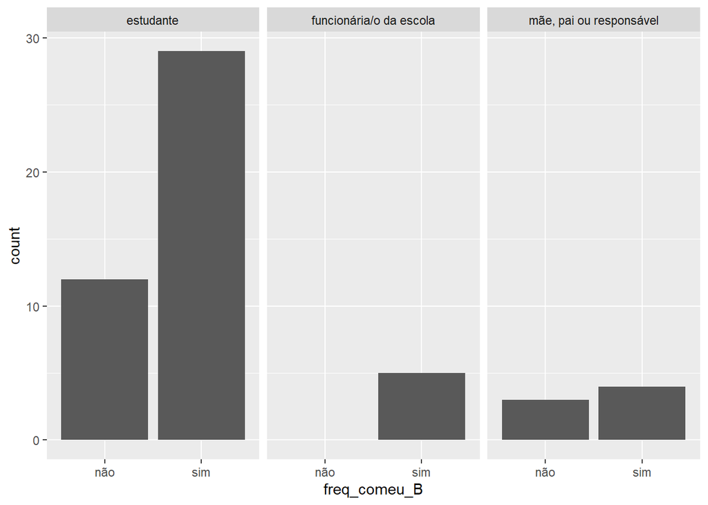

```
## [1] "questionário A"
```

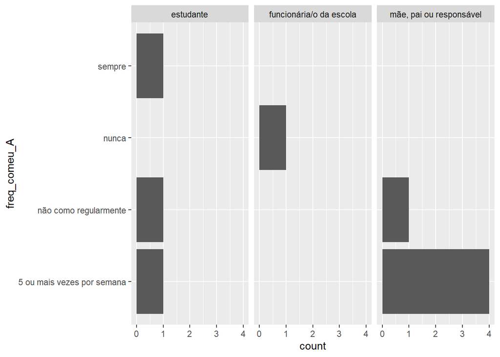

A partir de agora, as perguntas do questionário B e A são iguais, de forma que não mais distinguiremos a análise por tipo de resposta - iremos juntar as respostas.

## Qualidade da merenda

Quando perguntados sobre a qualidade da merenda (se achavam satisfatória), 30% disseram que não e 50% achavam satisfatória. O restante não soube ou não respondeu.

```
## # A tibble: 4 x 3
##   qualidade_merenda               total  perc
##   <chr>                           <int> <dbl>
## 1 não                                18 0.290
## 2 não sei / prefiro não responder    11 0.18
## 3 sim                                31 0.5
## 4 <NA>                                2 0.03
```

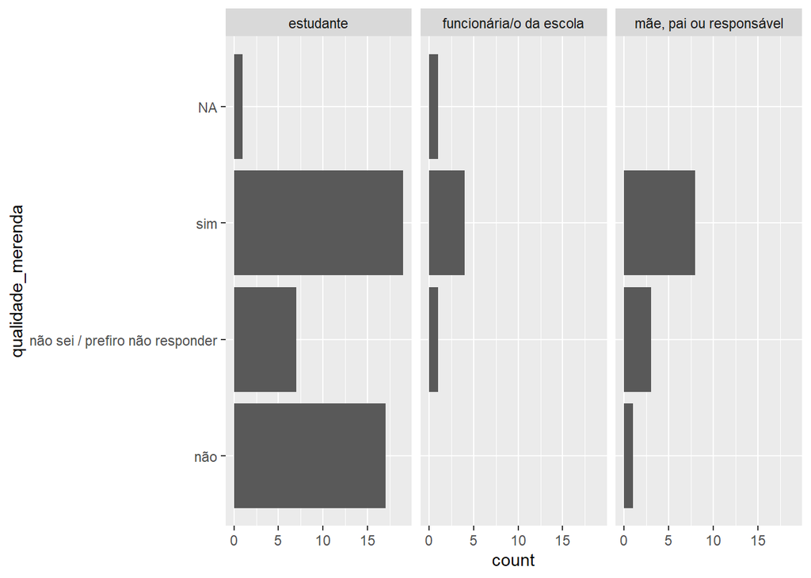

## Cardápio

Quando perguntados se o cardápio podia ser cosnultado, 44% disseram que não e 56% que sim. Cruzando por tipo de respondente, por UF (SP vs outros) e cidade, vemos que não há correlação entre a resposta e se é estudante, e alguma evidência de que pais e funcionários são mais propensos a achar que sim, o cardápio pode ser consultado. Quando olhamos para região, notamos que UF não é informativo, mas cidade é. No agregado não há diferença ser estudante e achar o cardápio, mas entre cidades isso muda. O que sugere que há variaçao de cidade na publicidade do cardápio (possivelmente entre escolas). Isso desaparece ao nível do estado, porque a variação é aleatório e uma coisa compensa a outra. Isso sugere que cidade (escolas?) é mais importante para explicar a variação nesse dado que o tipo de respondente.

```
## # A tibble: 2 x 3
##   cardapio_transparente total  perc
##   <chr>                 <int> <dbl>
## 1 não                      27  0.44
## 2 sim                      35  0.56
```

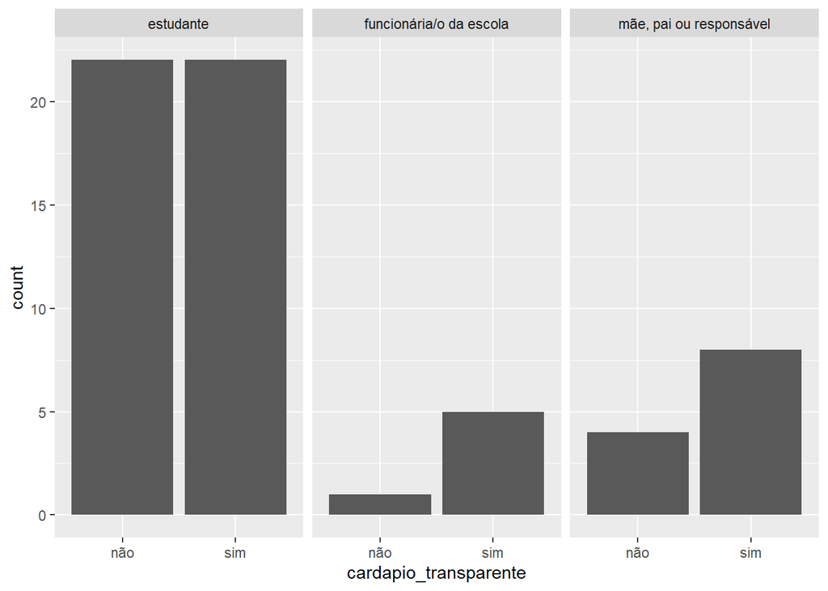

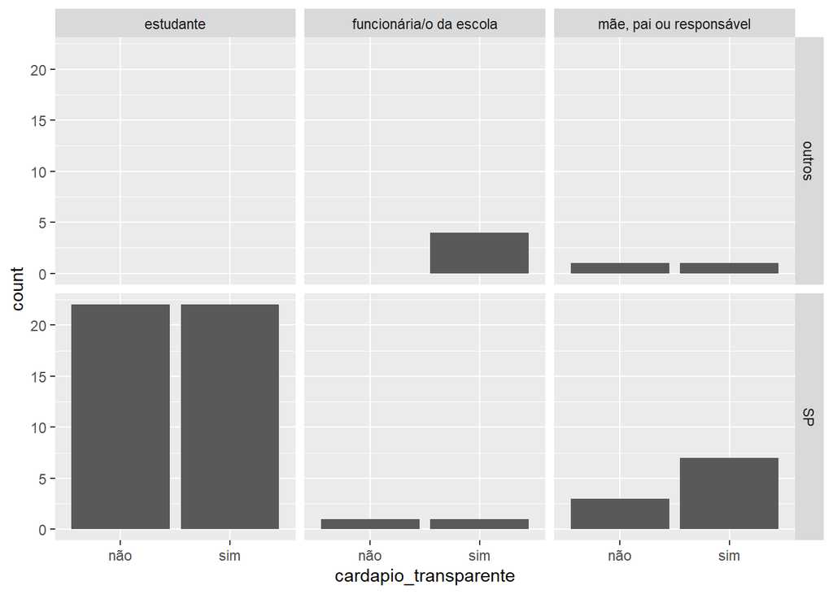

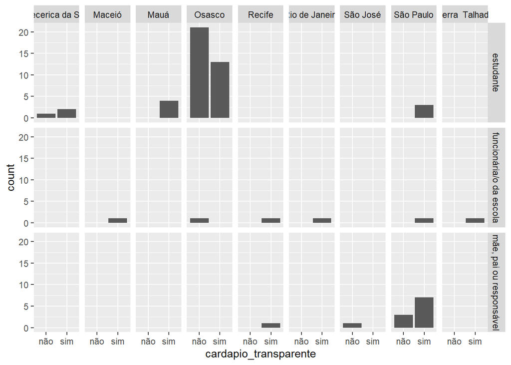

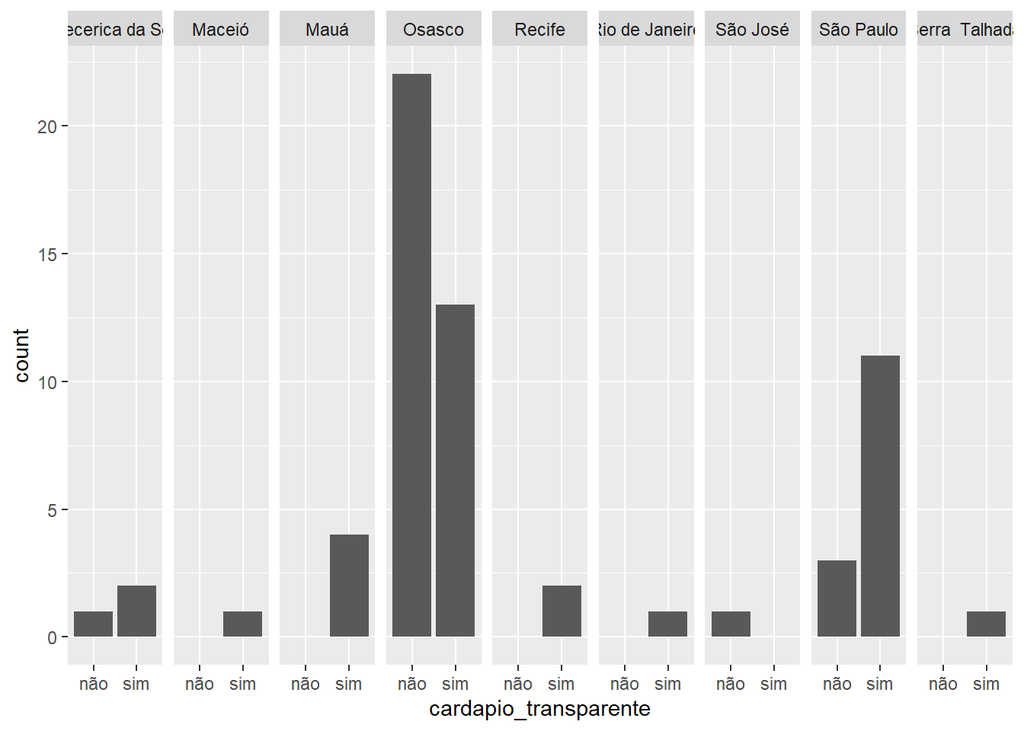

Demais perguntas sobre cardápio eram: 1. como consulta o cardápio e 2. se a merenda corresponde ao cardápio. Quarenta porcento não responderam à primeira pergunta. Então procuramos investigar se havia associação entre perfil do respondente e ter respondido à pergunta ou cidade e ter respondido à pergunta. A hipótese é que uma associação clara daria luz sobre a utilidade desta pergunta para determinado público alvo ou para cidades/escolas. Há uma associação, mas bem mais fraca que a encontrada sobre ter o cardápio disponível ou não. Precisaria investigar mais (aka coletar mais dados).

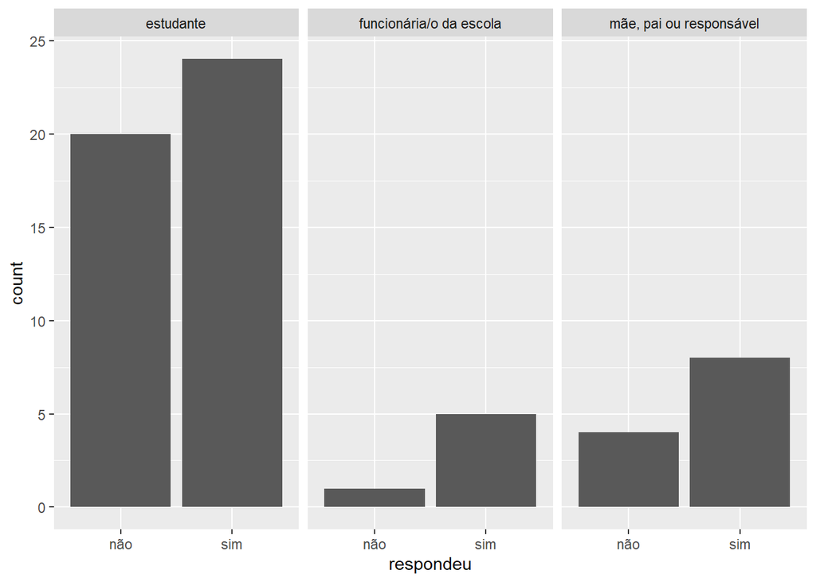

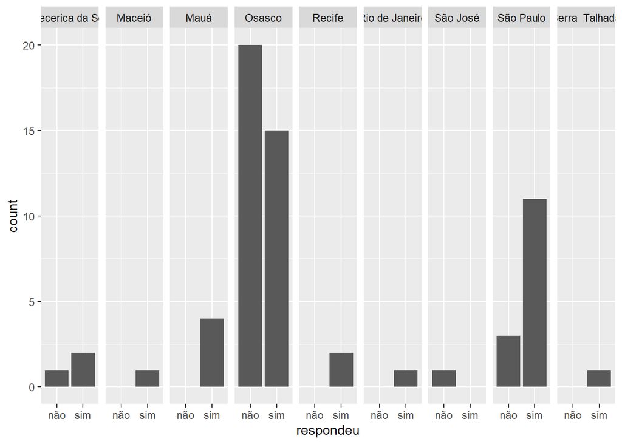

E abaixo temos as respostas de como eles acessam ao cardápio. Grosso modo, está disponível na parede.

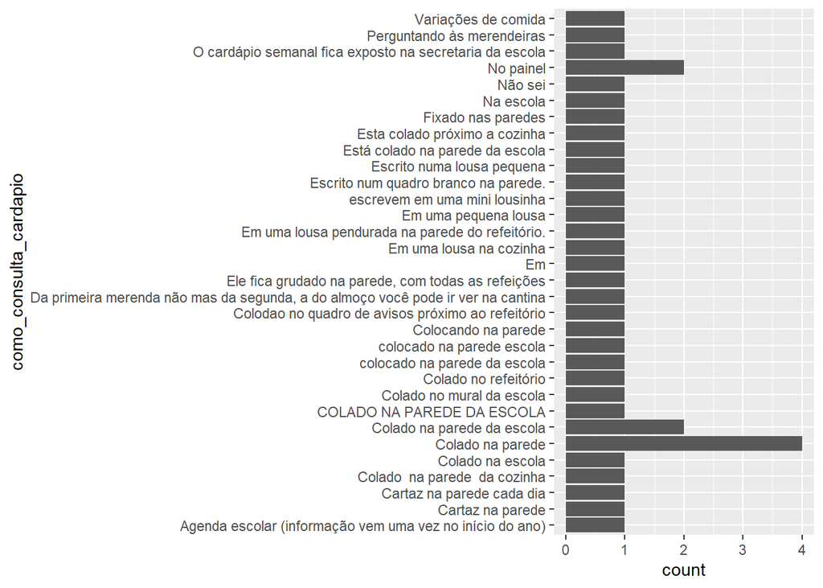

[output not shown]

Com relação à correspondência entre cardápio e merenda, olhando apenas para aqueles que responderam a pergunta acima, encontramos que o cardápio, via de regra, corresponde à merenda sempre ou quase sempre.

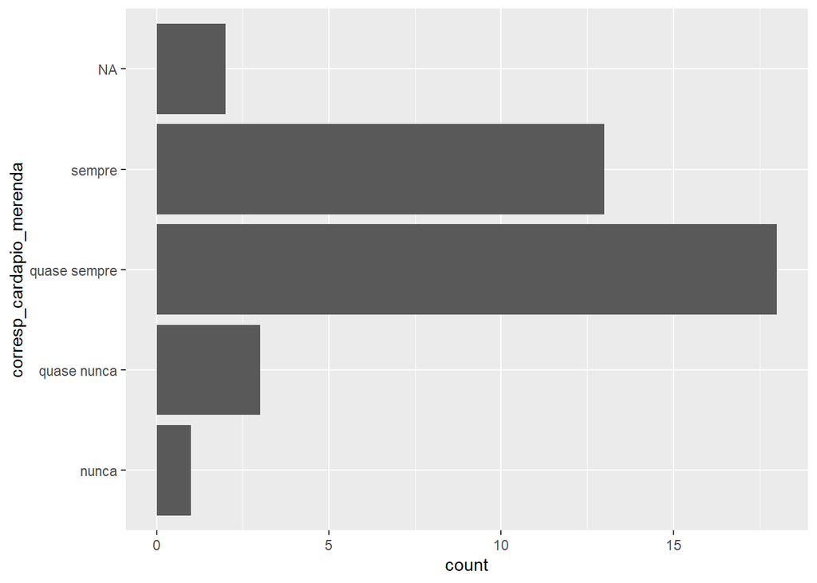

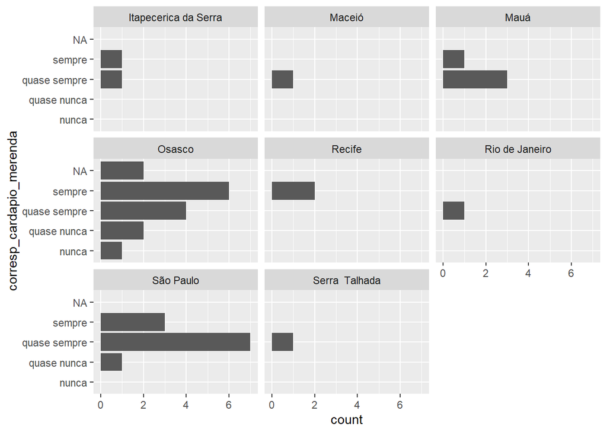

# Preparo da Merenda

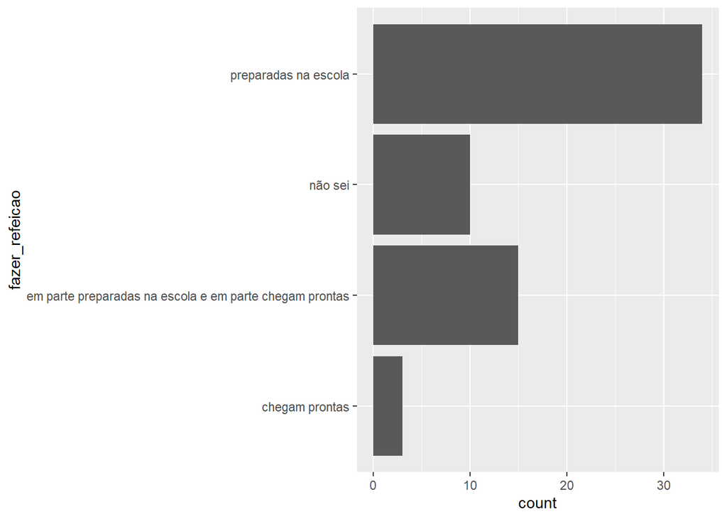

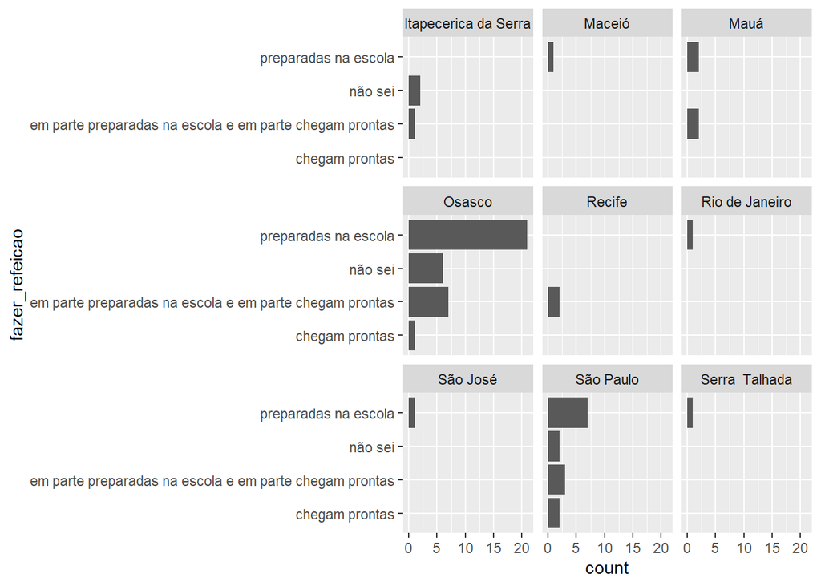